# Evidencia_1_Estadística_Multivariante

2023-11-19

# **VARIABLES CRÍTICAS PARA PRONOSTICAR EL VALOR DE INMUEBLES EN CDMX**

**Mariana Manzano Rico A01735770**

**Materia: Minería de Datos**

**Profesores: Dr. Yamil Burguete, Dr. Eric Larsen**

La CDMX es una de las ciudades más importantes del mundo así como de las más grandes, pues si bien su territorio es el más pequeño del País, tiene una de las más grandes poblaciones a nivel mundial. Tiene al menos cuatro escenarios reconocidos como Patrimonio de la Humanidad y un sin fin de actividades culturales, recreativas, de negocios, entre otras (México Desconocido, s.f.).

En ella viven al menos 9.21 millones de personas (INEGI, 2020), las cuales necesitan un hogar para vivir. Sin embargo, las diferencias en su calidad de vida varían dependiendo de su entorno, actividades profesionales y clases socioeconómicas.

Es por ello por lo que en este reporte nos enfocaremos en determinar cuáles son aquellas características que definen el valor de una casa y para qué segmento de mercado están dirigidos, haciendo uso de técnicas estadísticas y programación para definir dichas variables, generar insights y desarrollar estrategias de venta para nuestra empresa del caso “Erich Zann y Asociados”, la cual es una compañía sobresaliente en la industria inmobiliaria y que desean hacer uso de estas tecnologías para diferenciarse de sus competidores.

## Análisis y pre-procesamiento de la base de datos.

La base con la que contamos incluye diferentes variables que permiten comprender el comportamiento de los bienes inmuebles en la CDMX, esta puede ser visualizada en la siguiente tabla:

```
## <class 'pandas.core.frame.DataFrame'>
## RangeIndex: 658 entries, 0 to 657
## Data columns (total 23 columns):
##  #   Column         Non-Null Count  Dtype
## ---  ------         --------------  -----
##  0   Alcaldia       658 non-null    object
##  1   Colonia        658 non-null    object
##  2   X1             658 non-null    float64
##  3   X2             658 non-null    float64
##  4   X3             658 non-null    float64
##  5   X4             658 non-null    float64
##  6   X5             658 non-null    float64
##  7   X6             658 non-null    float64
##  8   X7             658 non-null    float64
##  9   X8             658 non-null    float64
##  10  X9             658 non-null    float64
##  11  X10            658 non-null    float64
##  12  Cocina_equip   658 non-null    object
##  13  Gimnasio       658 non-null    object
##  14  Amueblado      658 non-null    object
##  15  Alberca        658 non-null    object
##  16  Terraza        658 non-null    object
##  17  Elevador       658 non-null    object
##  18  m2_construido  658 non-null    float64
##  19  Baños          658 non-null    float64
##  20  Recamaras      658 non-null    int64
##  21  Lugares_estac  658 non-null    object
##  22  Precio_m2      658 non-null    float64
## dtypes: float64(13), int64(1), object(9)
## memory usage: 118.4+ KB
```

**Inspección de variables categóricas.**

En total contamos con 9 variables de este tipo, “Alcaldia” y “Colonia” hacen referencia a la ubicación de los inmuebles mientras que “Cocina_equip”,“Gimnasio”,“Amueblado”,“Alberca”,“Terraza”,“Elevador” y “Lugares_estac” hacen referencia a las amenidades con las que cuentan los inmuebles.

**Inspección de variables numéricas.**

Contamos con 14 variables de este tipo, desde la variable “X1” a “X10” nos describe la situación del entorno en la que se encuentra el inmueble como lo son la población analfabeta, que no asiste a la escuela, que no cuenta con servicios de salud, o viviendas con hacinamiento, sin agua entubada, energía eléctrica, celular o computadora, estas se miden según el porcentaje de la población total que lo padece. También observamos variables que de manera numérica nos ofrecen una descripción del inmueble como lo son “m2_construido”, “Baños”, “Recamaras” y “Precio_m2”. Esta última será nuestra variable de estudio.

### **Limpieza de datos categóricos**

Utilizamos la función “freq_tbl” para identificar los factores de cada categoría, a simple vista detectamos errores en la recopilación de los datos, existen caracteres con mayúsculas, con minúsculas o con espacios no adecuados, además verificamos que la variable “Lugares_estac” tendría que ser de naturaleza numérica pero encontramos una cadena, en este caso decidimos reemplazarlo por el valor “1”, a continuación procederemos a realizar la limpieza adecuada.

```
##                   Alcaldia  frequency  percentage  cumulative_perc
## 0               Iztapalapa         94    0.142857         0.142857
## 1           Alvaro Obregon         91    0.138298         0.281155
## 2                  Tlahuac         82    0.124620         0.405775
## 3        Gustavo A. Madero         79    0.120061         0.525836
## 4                 Coyoacan         45    0.068389         0.594225
## 5           Miguel Hidalgo         38    0.057751         0.651976
## 6      Venustiano Carranza         33    0.050152         0.702128
## 7             Azcapotzalco         30    0.045593         0.747720
## 8                  Tlalpan         29    0.044073         0.791793
## 9                Cuahtemoc         27    0.041033         0.832827
## 10           Benito Juárez         26    0.039514         0.872340
## 11              Xochimilco         24    0.036474         0.908815
## 12              Cuajimalpa         23    0.034954         0.943769
## 13  La Magdalena Contreras         19    0.028875         0.972644
## 14              Milpa alta         11    0.016717         0.989362
## 15               Iztacalco          7    0.010638         1.000000
##
## ----------------------------------------------------------------
##
##                   Colonia  frequency  percentage  cumulative_perc
## 0                Santa Fe         29    0.044073         0.044073
## 1                 Polanco         22    0.033435         0.077508
## 2               San Angel         13    0.019757         0.097264
## 3    San Jerónimo Líndice         11    0.016717         0.113982
## 4         Miguel Hidalgo          11    0.016717         0.130699
## ..                    ...        ...         ...              ...
## 309                Puebla          1    0.001520         0.993921
## 310           Xochinahuac          1    0.001520         0.995441
## 311           Xochicalli           1    0.001520         0.996960
## 312          Zona Escolar          1    0.001520         0.998480
## 313              Claveria          1    0.001520         1.000000
##
## [314 rows x 4 columns]
##
## ----------------------------------------------------------------
##
##   Cocina_equip  frequency  percentage  cumulative_perc
## 0           Si        555    0.843465         0.843465
## 1           No         62    0.094225         0.937690
```

[output cut: 40 more lines]

```
## 2      Si          34    0.051672         0.996960
## 3       si          2    0.003040         1.000000
##
## ----------------------------------------------------------------
##
##   Lugares_estac  frequency  percentage  cumulative_perc
## 0             1        384    0.583587         0.583587
## 1             2        163    0.247720         0.831307
## 2             3         54    0.082067         0.913374
## 3             0         43    0.065350         0.978723
## 4             4         11    0.016717         0.995441
## 5             5          2    0.003040         0.998480
## 6            Si          1    0.001520         1.000000
##
## ----------------------------------------------------------------
```

Posteriormente se hizo una nueva visualización para verificar que no hayan datos sucios y observamos que nuestra base de datos está casi lista para ser estudiada.

```
##                   Alcaldia  frequency  percentage  cumulative_perc
## 0               Iztapalapa         94    0.142857         0.142857
## 1           Alvaro Obregon         91    0.138298         0.281155
## 2                  Tlahuac         82    0.124620         0.405775
## 3        Gustavo A. Madero         79    0.120061         0.525836
## 4                 Coyoacan         45    0.068389         0.594225
## 5           Miguel Hidalgo         38    0.057751         0.651976
## 6      Venustiano Carranza         33    0.050152         0.702128
## 7             Azcapotzalco         30    0.045593         0.747720
## 8                  Tlalpan         29    0.044073         0.791793
## 9                Cuahtemoc         27    0.041033         0.832827
## 10           Benito Juárez         26    0.039514         0.872340
## 11              Xochimilco         24    0.036474         0.908815
## 12              Cuajimalpa         23    0.034954         0.943769
## 13  La Magdalena Contreras         19    0.028875         0.972644
## 14              Milpa alta         11    0.016717         0.989362
## 15               Iztacalco          7    0.010638         1.000000
##
## ----------------------------------------------------------------
##
##                   Colonia  frequency  percentage  cumulative_perc
## 0                Santa Fe         29    0.044073         0.044073
## 1                 Polanco         22    0.033435         0.077508
## 2               San Angel         13    0.019757         0.097264
## 3    San Jerónimo Líndice         11    0.016717         0.113982
## 4         Miguel Hidalgo          11    0.016717         0.130699
## ..                    ...        ...         ...              ...
## 309                Puebla          1    0.001520         0.993921
## 310           Xochinahuac          1    0.001520         0.995441
## 311           Xochicalli           1    0.001520         0.996960
## 312          Zona Escolar          1    0.001520         0.998480
## 313              Claveria          1    0.001520         1.000000
##
## [314 rows x 4 columns]
##
## ----------------------------------------------------------------
##
##   Cocina_equip  frequency  percentage  cumulative_perc
## 0           Si        596    0.905775         0.905775
## 1           No         62    0.094225         1.000000
```

[output cut: 17 more lines]

```
## 1      Si        112    0.170213         1.000000
##
## ----------------------------------------------------------------
##
##   Terraza  frequency  percentage  cumulative_perc
## 0      No        340    0.516717         0.516717
## 1      Si        318    0.483283         1.000000
##
## ----------------------------------------------------------------
##
##   Elevador  frequency  percentage  cumulative_perc
## 0       Si        358    0.544073         0.544073
## 1       No        300    0.455927         1.000000
##
## ----------------------------------------------------------------
```

### Verificación de outliers

Realizamos un boxplot con la metodología de las cercas de Tukey para identificar los posibles valores fuera de rango.

En primer lugar verificamos las variables “X1” hasta “X10”.

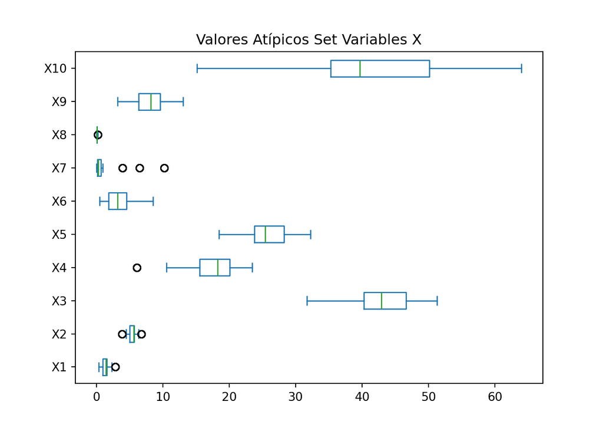

Después hacemos lo mismo para observar la columna de metros cuadrados construidos:

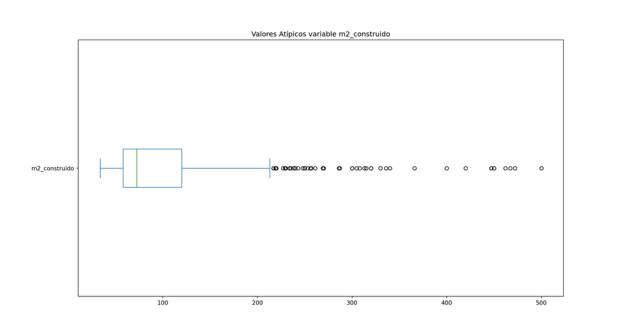

De igual manera observamos una seria de datos que sobresalen de los límites de las cercas.

Posteriormente lo repetimos para ver los valores en las amenidades de los inmuebles:

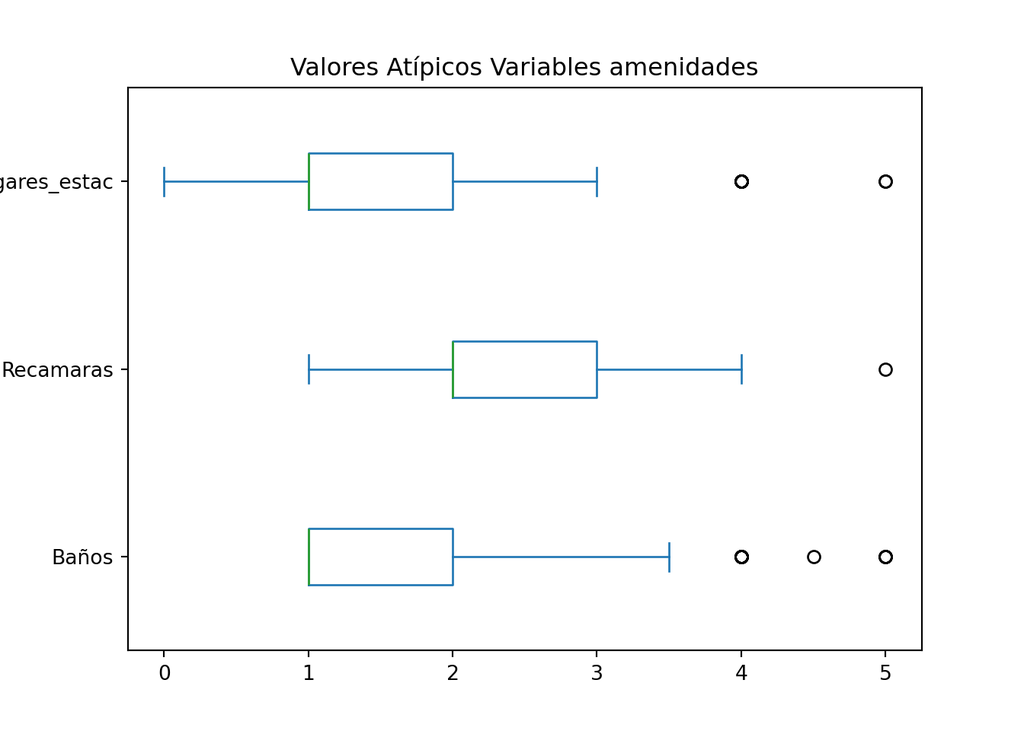

Sin embargo, consideramos que estos no son necesarios de limpiar debido a los valores presentados.

Finalmente lo repetimos para el valor de precio por metro cuadrado y observamos que hay un valor muy extremo, pero dado que es un solo valor, se decide eliminar dicho registro.

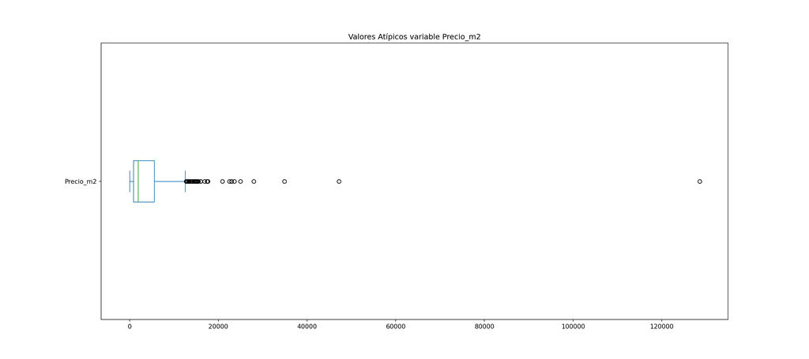

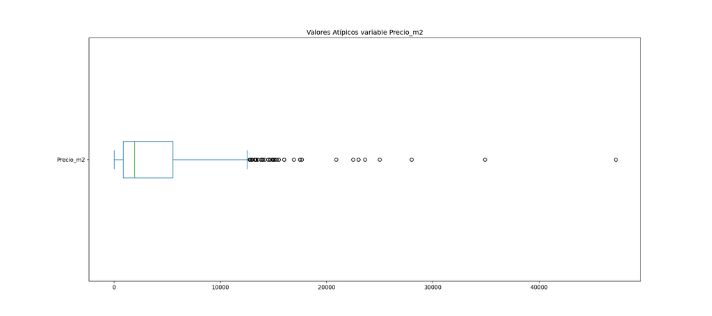

## Análisis de conglomerados.

Implementaremos un análisis de conglomerados para definir segmentos de mercado en el sector inmobiliario. Esta técnica nos permitirá agrupar propiedades similares según características clave, facilitando así una comprensión más detallada de las preferencias y tendencias del mercado. A través de este análisis, se buscará identificar patrones que permitan una estrategia de comercialización más enfocada y personalizada, optimizando la oferta de inmuebles de acuerdo con las necesidades específicas de cada segmento identificado.

### Selección de las variables

Para ello, decidimos usar las variables de precio por metros cuadrados y metros cuadrados de cada inmueble, pues estas dos variables forman el valor total de la casa y permitirán indicarnos cómo deben agruparse estas casas para llegar a distintos mercados.

```
##        m2_construido     Precio_m2
## count     657.000000    657.000000
## mean      103.338280   4094.677207
## std        76.023027   5007.717845
## min        34.000000      1.250000
## 25%        58.000000    860.657000
## 50%        72.000000   1918.080000
## 75%       120.000000   5524.000000
## max       500.000000  47200.000000
```

### Método de similitud o distancia

La decisión es utilizar el método euclidiano.

### Procedimiento de agrupamiento

Optamos por implementar el procedimiento k-means en este caso, ya que hemos categorizado la naturaleza de la información y buscamos llevar a cabo un análisis no jerárquico. Este enfoque implica la división de cada punto de datos en grupos de manera independiente, sin tener en cuenta la existencia de subgrupos o clusters dentro de otros clusters. El objetivo principal es lograr una clasificación clara y directa de los datos, simplificando así la interpretación de los resultados y permitiendo una segmentación efectiva de los bienes inmuebles en categorías distintas.

### Decidir número de conglomerados

Para definir el número de clústers utilizamos el método del codo, el cual nos dará una gráfica que indicará qué número de conglomerados final debemos de tener.

```
KMeans(n_clusters=10, random_state=42)
```

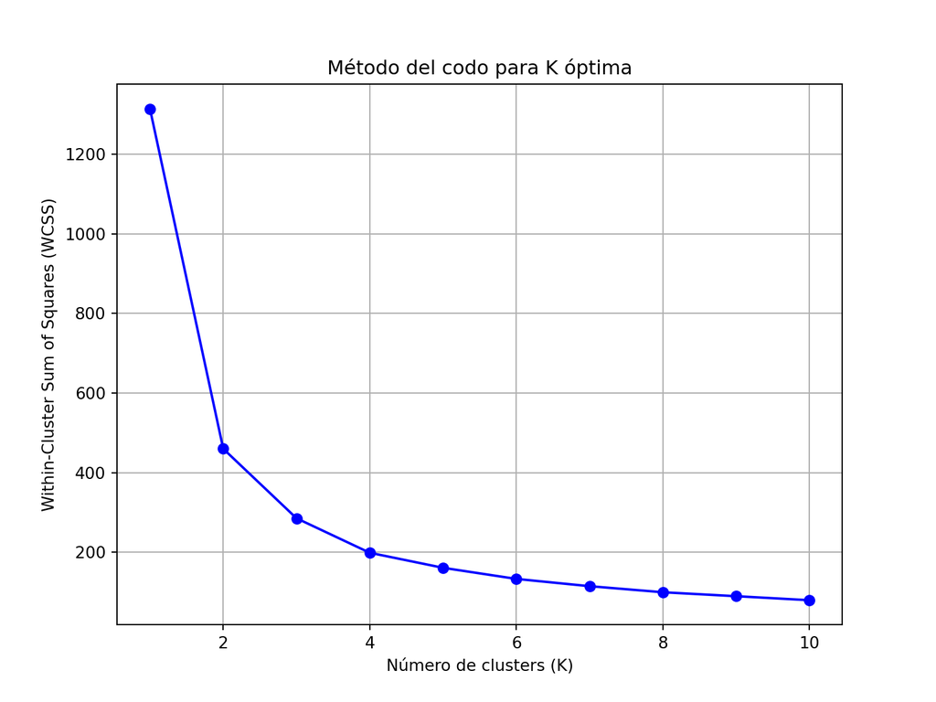

En este caso, nos dice que es de 4 conglomerados, pues es en este punto donde hay mayor diferencia entre clústers y menor diferencia dentro de ellos.

### División de Conglomerados

Posteriormente y ya sabiendo cuántos conglomerados necesitamos para tener un agrupamiento óptimo, procedemos a hacer la separación como se observa en las siguientes imágenes.

```
KMeans(n_clusters=4)
```

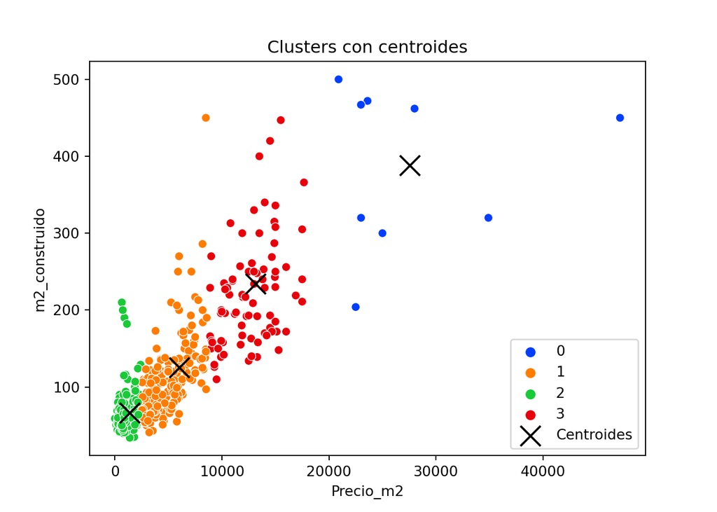

Podemos observar una división pura, pues los clústers están divididos a la perfección.

### Definición de los conglomerados.

**Perfil 3. C: Clase Media (Cluster1)**  
Este tipo de inmueble está diseñado para atraer a familias jóvenes, con una pareja que está dando sus primeros pasos en el desarrollo de sus carreras y con, como máximo, un hijo. Estas viviendas suelen contar con 2 habitaciones, cada una con baños integrados, espacio para estacionar de 1 a 2 vehículos, y un precio por metro cuadrado cercano a $4,909. Esta categoría representa aproximadamente el 30% de todos los registros y se alinea con lo que comúnmente se clasifica como clase media. Los individuos en este segmento tienen principalmente educación de nivel preparatoria. Las viviendas pertenecientes a este grupo pueden ser casas o departamentos, ya sea de propiedad o alquilados, con algunas comodidades (Gutiérrez, 2004).

Existen otras dos clases socioeconómicas que no entran en nuestro análisis, pues no tienen el poder adquisitivo de comprar una casa.

Ahora que ya sabemos cómo están divididos nuestros datos, podemos generar estrategias de marketing enfocadas en cada séctor, las cuales serán vistas más adelante.

## ANÁLISIS ANOVA

El análisis de varianza, conocido como ANOVA, es una técnica estadística utilizada para evaluar si existen diferencias significativas entre las medias de tres o más grupos. Su aplicación se centra en determinar si las variaciones observadas entre los grupos son estadísticamente significativas o simplemente producto del azar. Al calcular la relación entre estas variabilidades, ANOVA proporciona una prueba estadística que permite tomar decisiones informadas sobre si al menos uno de los grupos difiere significativamente de los demás.

En el caso se menciona que una de las características de los inmuebles que más influye en los precios es la ubicación, por lo cual nuestro objetivo es generar un análisis de este tipo para identificar si hay diferencias entre los precios de las alcaldías y determinar estrategias de ventas dependiendo de dichas diferencias.

Por otro lado, se cree que otras de las variables que influyen en el precio de un inmueble es si la cocina es equipada (cuenta con refrigerador, estufa, etc) y si tiene terraza. Es por ello que también se hará un análisis ANOVA de dos vías con ambas variables.

### OWA

En este primer análisis nos enfocaremos en la “Alcaldía” y “Precio_m2” las cuales serán nuestras variables de estudio. Para ello, primero generamos nuestras hipótesis del análisis.

**Hipótesis**  
La prueba de hipótesis queda declarada de la siguiente manera:  
• H0 = No existe diferencia significativa entre el precio por m2 y las distintas alcaldías de la CDMX.  
• H1 = Existe diferencia significativa entre el precio por m2 y las distintas alcaldías de la CDMX.

Procedemos a hacer el análisis con un nivel de significancia del 95%.

```
##                    Alcaldia  Precio_m2
## 0    La Magdalena Contreras    6500.00
## 1                   Tlahuac    1200.00
## 2                Cuajimalpa   17500.00
## 3                   Tlahuac    1046.40
## 4                   Tlahuac    1195.00
## ..                      ...        ...
## 653           Benito Juárez    5791.80
## 654                Coyoacan    2200.00
## 655  La Magdalena Contreras    1094.44
## 656              Iztapalapa     650.00
## 657            Azcapotzalco    3090.00
##
## [657 rows x 2 columns]
```

```
## ANOVA de una vía - Resultados:
```

```
## Puntaje F: 97.35
```

```
## P-valor: 0.0000
```

```
## Se rechaza la hipótesis nula. Existen diferencias significativas entre grupos.
```

La observación revela que el valor de p es inferior a 0.001, indicando que al menos uno de los factores en la variable “Alcaldía” presenta una diferencia estadísticamente significativa en cuanto al precio en comparación con las demás. En consecuencia, hemos optado por generar una representación gráfica con el objetivo de visualizar la distribución de los precios en cada una de estas ubicaciones.

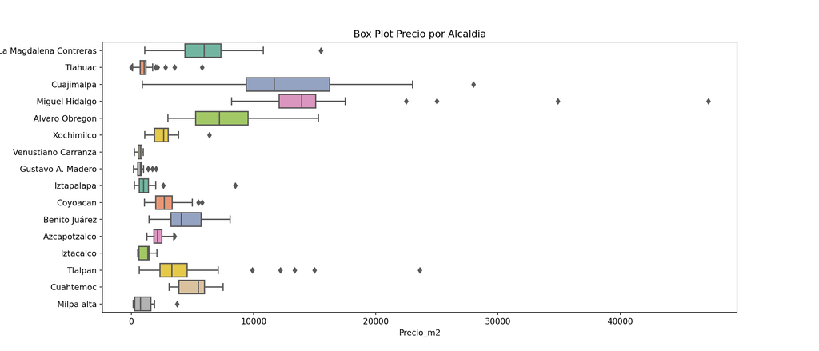

### Prueba Post-Hoc de Tukey

```
##
## Resultados Tukey-Kramer prueba Post Hoc:
```

```
##                       Multiple Comparison of Means - Tukey HSD, FWER=0.05
## ===============================================================================================
##         group1                 group2           meandiff  p-adj     lower       upper    reject
## -----------------------------------------------------------------------------------------------
##         Alvaro Obregon           Azcapotzalco  -5566.9318    0.0  -7595.9913  -3537.8724   True
##         Alvaro Obregon          Benito Juárez  -3259.6329    0.0  -5402.5585  -1116.7072   True
##         Alvaro Obregon               Coyoacan  -4959.7537    0.0  -6716.9707  -3202.5366   True
##         Alvaro Obregon              Cuahtemoc  -2612.6907 0.0025  -4724.6028   -500.7786   True
##         Alvaro Obregon             Cuajimalpa   5438.1324    0.0    3189.388   7686.8767   True
##         Alvaro Obregon      Gustavo A. Madero  -7098.1161    0.0  -8581.9818  -5614.2504   True
##         Alvaro Obregon              Iztacalco  -6656.3838    0.0 -10432.9894  -2879.7782   True
##         Alvaro Obregon             Iztapalapa  -6677.8293    0.0  -8097.2455   -5258.413   True
##         Alvaro Obregon La Magdalena Contreras   -808.0482  0.999    -3238.02   1621.9235  False
##         Alvaro Obregon         Miguel Hidalgo   7516.9355    0.0   5654.9428   9378.9282   True
##         Alvaro Obregon             Milpa alta  -6748.1787    0.0  -9822.3575  -3673.9998   True
##         Alvaro Obregon                Tlahuac  -6725.1179    0.0  -8194.4572  -5255.7787   True
##         Alvaro Obregon                Tlalpan  -2691.7812 0.0009   -4746.911   -636.6514   True
##         Alvaro Obregon    Venustiano Carranza   -7114.157    0.0  -9072.8229   -5155.491   True
##         Alvaro Obregon             Xochimilco   -5191.982    0.0  -7403.0983  -2980.8657   True
##           Azcapotzalco          Benito Juárez    2307.299 0.1412   -271.5906   4886.1886  False
##           Azcapotzalco               Coyoacan    607.1782 0.9999  -1661.3793   2875.7356  False
##           Azcapotzalco              Cuahtemoc   2954.2411 0.0076    401.0639   5507.4183   True
##           Azcapotzalco             Cuajimalpa  11005.0642    0.0   8337.5949  13672.5335   True
##           Azcapotzalco      Gustavo A. Madero  -1531.1843 0.4349  -3595.2576     532.889  False
##           Azcapotzalco              Iztacalco   -1089.452 0.9999  -5129.4137   2950.5098  False
##           Azcapotzalco             Iztapalapa  -1110.8974 0.8784  -3129.1352    907.3403  False
##           Azcapotzalco La Magdalena Contreras   4758.8836    0.0   1936.9509   7580.8163   True
##           Azcapotzalco         Miguel Hidalgo  13083.8674    0.0  10733.2168  15434.5179   True
##           Azcapotzalco             Milpa alta  -1181.2468 0.9983  -4573.7557   2211.2621  False
##           Azcapotzalco                Tlahuac  -1158.1861 0.8563  -3211.8411    895.4689  False
##           Azcapotzalco                Tlalpan   2875.1506 0.0086    368.7389   5381.5624   True
##           Azcapotzalco    Venustiano Carranza  -1547.2251 0.7026  -3975.1694    880.7191  False
##           Azcapotzalco             Xochimilco    374.9499    1.0  -2260.8757   3010.7755  False
##          Benito Juárez               Coyoacan  -1700.1208 0.4979  -4071.0702    670.8286  False
##          Benito Juárez              Cuahtemoc    646.9422    1.0    -1997.63   3291.5143  False
##          Benito Juárez             Cuajimalpa   8697.7652    0.0   5942.6899  11452.8406   True
##          Benito Juárez      Gustavo A. Madero  -3838.4833    0.0  -6014.5914  -1662.3752   True
##          Benito Juárez              Iztacalco   -3396.751 0.2433  -7495.0846    701.5827  False
##          Benito Juárez             Iztapalapa  -3418.1964    0.0  -5550.8782  -1285.5146   True
##          Benito Juárez La Magdalena Contreras   2451.5846 0.2163   -453.2996   5356.4688  False
```

[output cut: 70 more lines]

```
##         Miguel Hidalgo                Tlahuac -14242.0535    0.0 -16130.8185 -12353.2884   True
##         Miguel Hidalgo                Tlalpan -10208.7167    0.0 -12581.9074   -7835.526   True
##         Miguel Hidalgo    Venustiano Carranza -14631.0925    0.0 -16921.2557 -12340.9292   True
##         Miguel Hidalgo             Xochimilco -12708.9175    0.0 -15218.4017 -10199.4333   True
##             Milpa alta                Tlahuac     23.0607    1.0  -3067.4072   3113.5287  False
##             Milpa alta                Tlalpan   4056.3975 0.0048    648.2319   7464.5631   True
##             Milpa alta    Venustiano Carranza   -365.9783    1.0  -3716.8597   2984.9031  False
##             Milpa alta             Xochimilco   1556.1967 0.9791   -1948.239   5060.6324  False
##                Tlahuac                Tlalpan   4033.3368    0.0   1953.9197   6112.7538   True
##                Tlahuac    Venustiano Carranza    -389.039    1.0  -2373.1733   1595.0952  False
##                Tlahuac             Xochimilco    1533.136 0.5779   -700.5721   3766.8441  False
##                Tlalpan    Venustiano Carranza  -4422.3758    0.0  -6872.1492  -1972.6024   True
##                Tlalpan             Xochimilco  -2500.2008 0.0914  -5156.1475    155.7459  False
##    Venustiano Carranza             Xochimilco    1922.175 0.4283   -659.8526   4504.2026  False
## -----------------------------------------------------------------------------------------------
```

En esta tabla, podemos observar la diferencia de precios entre alcaldías más claramente, (las que dicen TRUE específicamente). Es con estas alcaldías significativamente diferentes a las demás, donde tenemos que aplicar diferentes estrategias de venta que impacten de manera correcta. Estas serán presentadas más adelante.

## 2WA

Como se mencionó con anterioridad, deseamos conocer si las amenidades que se ofrecen también impactan en el precio de una casa, por lo que procedemos a hacer el análisis de dos vías.

**Hipótesis Cocina equipada**  
• H0 = No existe diferencia em el precio por m2 respecto a si cuenta con cocina equipada.  
• H1 = Existe diferencia en el precio precio por m2 respecto a si cuenta con cocina equipada

**Hipótesis Terraza**  
• H0 = No existe diferencia em el precio por m2 respecto a si el inmueble tiene terraza.  
• H1 = Existe diferencia en el precio precio por m2 respecto a si el inmueble tiene terraza.

```
## Resultados ANOVA de dos vías:
```

```
##                     sum_sq     df           F        PR(>F)
## Cocina_equip  2.763018e+07    1.0    1.547823  2.139029e-01
## Terraza       4.182212e+09    1.0  234.284450  1.990494e-45
## Residual      1.167455e+10  654.0         NaN           NaN
```

Observamos las diferencias de casas con terrazas y casas sin terraza, así como si incluyen o no cocina equipada. Notamos que sí hay diferencias entre las que cuentan y no con terraza, pero esto no es tan visible en si cuentan o no con cocina equipada.

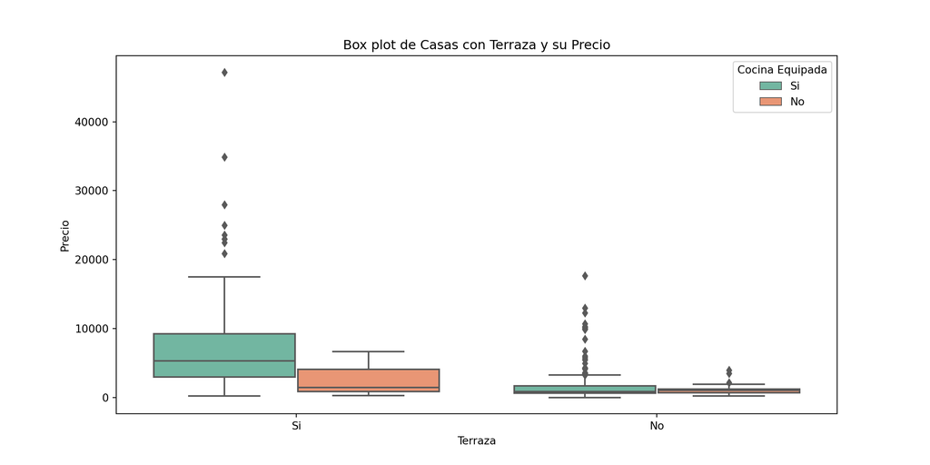

Finalmente, para determinar en qué grupos hay diferencias específicamente, generamos la prueba Post Hoc de Tukey.

### Prueba Post-Hoc de Tukey

```
##
## Resultados de la prueba Tukey HSD para Inmuebles con Terraza:
```

```
##   Multiple Comparison of Means - Tukey HSD, FWER=0.05
## ========================================================
## group1 group2  meandiff p-adj   lower     upper   reject
## --------------------------------------------------------
##     No     Si 5380.1087   0.0 4732.1046 6028.1128   True
## --------------------------------------------------------
```

```
##
## Resultados de la prueba Tukey HSD para Inmuebles con Cocina Equipada:
```

```
##   Multiple Comparison of Means - Tukey HSD, FWER=0.05
## ========================================================
## group1 group2  meandiff p-adj   lower     upper   reject
## --------------------------------------------------------
##     No     Si 3252.2621   0.0 1962.9254 4541.5989   True
## --------------------------------------------------------
```

## CLASIFICACIÓN BAYESIANA

Un modelo de clasificación bayesiana es un enfoque estadístico que se basa en el teorema de Bayes para realizar tareas de clasificación. Este método utiliza la probabilidad condicional para asignar categorías a nuevos datos, considerando la información previa y la evidencia acumulada. Se apoya en la actualización de creencias a medida que se obtiene nueva información, permitiendo una adaptación continua del modelo.

Este será utilizado para pronosticar en qué categoría socioeconómica entra cada nueva casa dependiendo de las amenidades que presenten como:

- Cocina equipada
- Gimnasio
- Amueblado
- Alberca
- Terraza
- Elevador
- Baños
- Récamaras
- Lugares de estacionamiento

Para ello, primero debemos cambiar los valores categóricos a numéricos, de modo que si un inmueble cuenta con cierta característica tenga un 1 como Sí y 0 como No.

Por otro lado, nuestra variable que será pronosticada es “Clústers”, una nueva variable que nos indica a qué grupo socioeconómico pertenece cada casa, basado en nuestro primer análisis de conglomerados.

### Evaluación del Modelo

Es necesario hacer una evaluación del modelo para saber si este tiene buenos resultados, por lo que dividimos nuestra base de datos actual en entrenamiento y test con una proporción de 80/20 respectivamente. Con el primer set de datos entrenaremos a nuestro modelo y con la segunda haremos un test para identificar la precisión y exactitud del modelo.

Es así como obtenemos los siguientes resultados:

```
MultinomialNB()
```

```
## Comparación de Métricas:
```

```
## Clasificador: Naive Bayes Multinomial
## Exactitud: 0.67
## Puntaje F1: 0.62
## Precisión: 0.58
## Sensibilidad (Recall): 0.67
```

Esto nos indica que el modelo es capaz de predecir con exactitud el 67% de las veces y tiene una precisión del 58%. Si bien estas variables no son excelentes, son lo suficientemente buenas para aplicarlas en nuestros pronósticos.

### Modelo de predicción

Finalmente, contamos con nuestro modelo para predicciones y haremos la siguiente prueba:

Un inmueble que tenga las siguientes características:

- Cocina equipada: Sí
- Gimnasio: No
- Amueblado: No
- Alberca: Sí
- Terraza: Sí
- Elevador: Sí
- Baños: 3
- Récamaras: 3
- Lugares de estacionamiento: 2

[output not shown]

## Recomendaciones y Conclusiones

Con todo ete análisis de información, hacemos las siguientes recomendaciones a la empresa:

1. **Estrategias de Marketing para Cada Cluster:** Para cada cluster identificado en nuestro análisis, implementaremos estrategias de marketing personalizadas. Por ejemplo, para el Clúster 0, que representa propiedades de lujo en áreas selectas, nos enfocaremos en campañas que resalten el estilo de vida exclusivo y las comodidades de estos inmuebles. Para el Clúster 3, que se orienta a la clase media alta, nuestras estrategias se centrarán en destacar la accesibilidad y el confort familiar de estas viviendas.

La aplicación de métodos estadísticos en el análisis de datos permite encontrar valiosos insights que sirven como base para el desarrollo de estrategias efectivas. Este enfoque técnico permite a las empresas identificar patrones, segmentos de mercado y variables clave que influyen en sus operaciones. En un mercado inmobiliario cada vez más competitivo, el uso de tecnologías estadísticas no solo es una herramienta, sino una ventaja competitiva. A pesar del tecnicismo de estos métodos, la creatividad desempeña un papel fundamental al interpretar los resultados y diseñar estrategias innovadoras. La combinación de análisis estadísticos y la creatividad estratégica permite que las empresas estén no solo informadas, sino que también puedan destacar y adaptarse de manera efectiva en la industria.

## Bibliografía

- México Desconocido. S.f. Monografía del Distrito Federal. México Desconocido. https://www.mexicodesconocido.com.mx/mexico-estados-monografia-distrito-federal.html#:~:text=Ubicado%20en%20la%20regi%C3%B3n%20Centro%2C%20el%20DF%20%28Ciudad,la%20ciudad%20m%C3%A1s%20grande%20y%20compleja%20del%20mundo.
- INEGI, 2020. Población de la CDMX. INEGI. https://www.inegi.org.mx/contenidos/saladeprensa/boletines/2021/EstSociodemo/ResultCenso2020_CdMx.pdf
- Gutiérrez, F. (2004). Clasificación de niveles socioeconómicos en México según la AMAI. Fernando Gutiérrez. https://www.fergut.com/clasificacion-de-niveles-socioeconomicos-en-mexico-segun-la-amai/